# STSCI 5065 - Final Project

Harry Lu

dl947

In this project, you will work on flight delay datasets. The data files are compressed into a file called `flightDelays.tar.gz`, which contains 12 separate files and can be downloaded from the course website under Final Project. You will load the data files into HDFS with different methods, manipulate and analyze the data based on the specifications in the following questions.

# Problem 1

In the command line interface (CLI), create an HDFS folder, `/final_project/data`. Download `flightDelays.tar.gz` with your web browser and then load the file into your HDFS folder, `/final_project/data`, using the Files View in Ambari. Attach a screenshot of your Files View showing this file.

```bash
[root@sandbox ~]# hadoop fs -mkdir /final_project
```

```bash
[root@sandbox ~]# hadoop fs -mkdir /final_project/data
```

[figure not shown]

# Problem 2

Create a directory `FP` (a non-HDFS directory) at the CentOS root. Use a command to copy `flightDelays.tar.gz` to `/FP` and use another command to decompress and untar `flightDelays.tar.gz`. Make sure that your `/FP` directory only contains the 12 newly created files all the time; delete any other files if any. Display the contents of the `/FP` directory (using the long listing and human readable format) and attach a screenshot.

```bash
[root@sandbox /]# mkdir /FP
```

```bash
[root@sandbox /]# hadoop fs -copyToLocal /final_project/data/flightDelays.tar.gz /FP/flightDelays.tar.gz
```

```
[root@sandbox /]# cd /FP
```

```
[root@sandbox FP]# ls
flightDelays_10.csv  flightDelays_1.csv  flightDelays_4.csv  flightDelays_7.csv  flightDelays.tar.gz
flightDelays_11.csv  flightDelays_2.csv  flightDelays_5.csv  flightDelays_8.csv
flightDelays_12.csv  flightDelays_3.csv  flightDelays_6.csv  flightDelays_9.csv
```

```bash
[root@sandbox FP]# rm flightDelays.tar.gz
rm: remove regular file `flightDelays.tar.gz'? y
```

```
[root@sandbox FP]# ls
flightDelays_10.csv  flightDelays_12.csv  flightDelays_2.csv  flightDelays_4.csv  flightDelays_6.csv  flightDelays_8.csv
flightDelays_11.csv  flightDelays_1.csv   flightDelays_3.csv  flightDelays_5.csv  flightDelays_7.csv  flightDelays_9.csv
```

```bash
[root@sandbox FP]# ls -lh
total 764M
-rw-r--r-- 1 1276589696 11103514 64M Apr  3  2015 flightDelays_10.csv
-rw-r--r-- 1 1276589696 11103514 60M Apr  3  2015 flightDelays_11.csv
-rw-r--r-- 1 1276589696 11103514 63M Apr  3  2015 flightDelays_12.csv
-rw-r--r-- 1 1276589696 11103514 61M Apr  3  2015 flightDelays_1.csv
-rw-r--r-- 1 1276589696 11103514 57M Apr  3  2015 flightDelays_2.csv
-rw-r--r-- 1 1276589696 11103514 67M Apr  3  2015 flightDelays_3.csv
-rw-r--r-- 1 1276589696 11103514 65M Apr  3  2015 flightDelays_4.csv
-rw-r--r-- 1 1276589696 11103514 66M Apr  3  2015 flightDelays_5.csv
-rw-r--r-- 1 1276589696 11103514 67M Apr  3  2015 flightDelays_6.csv
-rw-r--r-- 1 1276589696 11103514 70M Apr  3  2015 flightDelays_7.csv
-rw-r--r-- 1 1276589696 11103514 68M Apr  3  2015 flightDelays_8.csv
-rw-r--r-- 1 1276589696 11103514 61M Apr  3  2015 flightDelays_9.csv
```

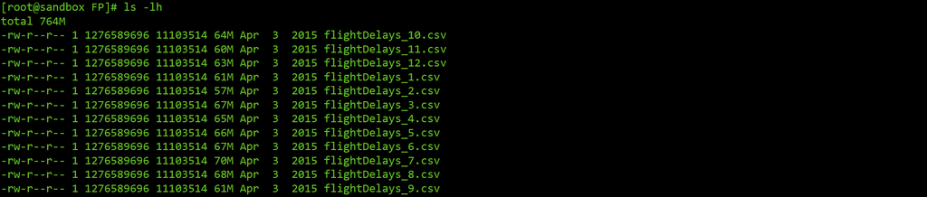

# Problem 3

Load the 12 files from the `FP` directory to the HDFS directory, `/final_project/dat`. Use three different approaches to load these files. Describe each of your approach and attach a screenshot of the result of each method. Note that at the beginning of a new method, you need to delete the files loaded previously and get ready for the next method to load the same files.

# Problem 4

Use Hive CLI to create a database called `FPdb`, located in `/final_project`. Describe the database after its creation. Attach a screenshot.

# Problem 5

Use a Pig script in Ambari to create a relation called `flightDelays` to load all the 12 files **with a single LOAD statement**. You use the following column names: `YEAR`, `FL_DATE`, `UNIQUE_CARRIER`, `CARRIER`, `FL_NUM`, `ORIGIN_AIRPORT_ID`, `ORIGIN`, `ORIGIN_CITY_NAME`, `ORIGIN_STATE_ABR`, `DEST_AIRPORT_ID`, `DEST`, `DEST_CITY_NAME`, `DEST_STATE_ABR`, `DEP_DELAY_NEW`, `ARR_DELAY`, `ARR_DELAY_NEW`, `CARRIER_DELAY`, `WEATHER_DELAY`, `NAS_DELAY`, `SECURITY_DELAY`, and `LATE_AIRCRAFT_DELAY`. If a column name contains the word “DELAY”, assign the **float** data type to it. Leave all other columns the **chararray** data type, except the YEAR column, which has an **int** data type. When you list the column names, please list one column name per line. Note that the data files contain a special data format: some values are enclosed in quotation marks but there is a comma within that value. Name your pig script `flightDelays`. Attach a screenshot showing that you successfully ran your pig script, including the logs.

# Problem 6

Based on the `flightDelays` relation, calculate the **average delays** (rounded to two decimal points) of the following delay categories: `CARRIER_DELAY`, `WEATHER_DELAY`, `NAS_DELAY`, `SECURITY_DELAY`, and `LATE_AIRCRAFT_DELAY`. Name your pig script `averageDelays`. Attach a screenshot showing that you successfully ran your pig script, including the logs.

# Problem 7

Based on the `flightDelays` relation, calculate the **longest delays** of the following delay categories: `CARRIER_DELAY`, `WEATHER_DELAY`, `NAS_DELAY`, `SECURITY_DELAY`, and `LATE_AIRCRAFT_DELAY`. Name your pig script `longestDelays`. Attach a screenshot showing that you successfully ran your pig script, including the logs.

# Problem 8

Find out all the information (e.g., the flight number, date, and airports, etc.) that was related to the longest `CARRIER_DELAY`, 1975.0 minutes. Write a Python UDF to go with your Pig script to produce an output like the following screenshot (use the same language and layout). Name your Python file `flight_delay_udf.py` and save it in the `/FP` directory. Name your UDF `get_max`. You are required to send the values from the Pig script to the Python UDF with a tuple of tuples. List your Python code and Pig script. Name your pig script `flight_delays_udf`. Attach a screenshot showing that you successfully ran your pig script, including the logs.

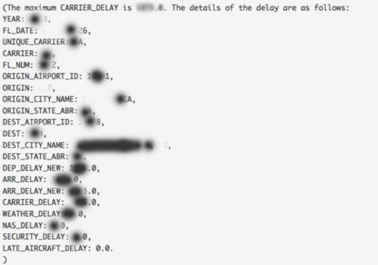

# Problem 9

Create a new relation named `allTheDelays` based on the `flightDelays` relation by only including the following columns: `FL_DATE`, `FL_NUM`, `CARRIER_DELAY`, `WEATHER_DELAY`, `NAS_DELAY`, `SECURITY_DELAY` and `LATE_AIRCRAFT_DELAY`, and then created another relation called `theDelays` based on the `allTheDelays` relation by only including the rows whose columns of `CARRIER_DELAY`, `WEATHER_DELAY`, `NAS_DELAY`, `SECURITY_DELAY` and `LATE_AIRCRAFT_DELAY` are not null. Store `theDelays` to the following HDFS directory: `/final_project/theDelays`. Name your pig script `allTheDelays`. Attach a screenshot showing that you successfully ran your pig script, including the logs.

After that, you should see eight files in the above directory. Navigate to the directory with the Files View in Ambari, and delete the file named `_SUCCESS`. Attach a screenshot of the contents of your `/final_project/theDelays` directory.

# Problem 10

With the seven files in the `/final_project/theDelays` directory, create seven Hive tables, `fd1_t` to `fd7_t` in the `FPdb` database (if your computer produces a different number of files other than 7, create the first three files, i.e., `fd1_t` to `fd3_t`, exactly as specified below in steps a and b; for creating the rest of your tables, use the method in step c):

## Step a)

In Hive View, create the first two tables `fd1_t` and `fd2_t` by loading `part-m-00000` and `part-m-00001` respectively. Note that the field values are separated by tabs. Use the same column names as defined in Pig, and set the data types of the first two columns (`FL_DATE` and `FL_NUM`) to **string** and the other five columns to **double**. Attach a screenshot of the screen when you create `fd1_t`, right before you are ready to click the “Upload Table” button.

Open the tables in Hive View and attach a screenshot of the first 10 rows of each table.

## Step b)

With the Query Editor in Hive View, define the third table, `fd3_t`, with the same column names and data types as in `fd1_t`. Load `part-m-00002` into `fd3_t`. Do a query to display the first 10 rows of `fd3_t`. Attach a screenshot.

## Step c)

In Hive View, create the rest of tables (`fd4_t` to `fd7_t`) based on the table definition of `fd3_t` and load the rest of data files (`part-m-00003` to `part-m-00006`) respectively. Do a query to display the first 10 rows of `fd7_t`. Attach a screenshot.

# Problem 11

In Hive View, use HiveQL to create a new table called `fd_t` by combining the seven Hive tables created above. Use the “describe formatted” command in Hive CLI to describe `fd_t` and attach a screenshot of your result.

# Problem 12

Query your `fd_t` table to find out the **longest delays** and the **average delays** (round to 2 decimal points) of each delay category. Assign an alias to each result with the `max_` or `mean_` prefix to the column names, e.g., `max_carrier_delay`. You should see the same results as you got previously in Pig scripting.

# Problem 13

Create a Hive view called `averageDelays_v`, which can produce the average delay results of Question 12. Use vi to create a **Python UDF** for Hive to find out the delay category that has the longest average delay time. Name the Python file as `FindMaxAverageDelayType.py`. List your Python code. Use your UDF in Hive CLI to run your Hive script. Attach a screenshot containing your Hive script (your text version of this script must also be included in your submission since we will run your script), Hive system log and the output of your Hive script. Your output should say that “The delay category with the longest average delay is XX; the average delay time is YY minutes.” Here, XX and YY are replaced by actual values in your report.

# Problem 14

It will be interesting to know if these delay categories are correlated or not. If they are, and then to what degree are they correlated? A common measure for this is the Pearson Correlation Coefficient (r), which can be calculated with the following formula:

$$r=\frac{n\left(\sum{xy}\right)-\left(\sum{x}\right)\left(\sum{y}\right)}{\sqrt{\left[n\left(\sum{x^2}\right)-\left(\sum{x}\right)^2\right]\left[n\left(\sum{y^2}\right)-\left(\sum{y}\right)^2\right]}}$$

or with a Hive built-in function, `CORR(col1, col2)`, where `col1` and `col2` are two numeric Hive table columns. Query the `fd_t` table to calculated the r value (round to 4 decimal points, the same below) of the `weather_delay` and the `carrier_delay` categories with both methods. You should get the same results with these two methods. Assign an alias to each result. For example, use `w_c` as an alias for the `weather_delay` and `carrier_delay` pair. After that, use the `CORR()` function to calculate all the r values of the 10 possible pairs of delay categories, **in a single query**; use aliases for all your pairs. Comment on your results, and attach screenshots of your results. (Hint: you will need to use several Hive built-in functions to calculate the r values with the formula.)